# 2 Demographic Variables

## Preparations

### Packages

**Click to see code**

```r
pacman::p_load(tidyverse, haven, here, psych, openxlsx, conflicted)

# Several packages we (or their dependencies) load define their own versions
# of common dplyr verbs (e.g., MASS::select()). Rather than fixing this one
# call at a time, we declare our preference once, globally, for the rest of
# the session: dplyr's version always wins, regardless of what else gets
# attached later or in what order.
conflicts_prefer(dplyr::select)
```

```
[conflicted] Will prefer dplyr::select over any other package.
```

**Click to see code**

```r
conflicts_prefer(dplyr::filter)
```

```
[conflicted] Will prefer dplyr::filter over any other package.
```

**Click to see code**

```r
conflicts_prefer(dplyr::rename)
```

```
[conflicted] Will prefer dplyr::rename over any other package.
```

**Click to see code**

```r
conflicts_prefer(dplyr::summarize)
```

```
[conflicted] Will prefer dplyr::summarize over any other package.
```

## Import Dataset

**Click to see code**

```r
p2_data <- readRDS("work_data/p1_data.Rds")
```

## Creating Demographic Variables

Our survey asked participants to select **all** race/ethnicity, sexual identity, and religious affiliation categories that applied to them (i.e., check-all-that-apply items), while gender identity was a single-select item. This means the raw variables need to be collapsed into single, categorical variables before we can use them in analysis. Below we walk through that process for each of our four key demographic variables: race/ethnicity, gender identity, sexual orientation, and religious identity/affiliation.

### Race and Ethnicity

Race and ethnicity was captured across 11 check-all-that-apply items (`rei_1`-`rei_11`), corresponding to White, Black, Asian, Pacific Islander, Native American, Native Hawaiian, MENA, Latine, Multiracial, Another racial identity, and Prefer not to answer, respectively. We’ll collapse these into a single `race` variable across four steps.

#### Step 1: Combine selections into a single string

First we recode missing values on each `rei_*` item to 0 (not selected), then paste together the labels of every category a participant selected into one string (`race_combo`). Respondents who selected nothing are labeled `"None selected"`.

**Click to see code**

```r
p2_data <- p2_data %>%
  mutate(
    across(all_of(paste0("rei_", 1:11)), ~ ifelse(is.na(.x), 0, .x)),

    race_combo = paste0(
      ifelse(rei_1 == 1, "White_", ""),
      ifelse(rei_2 == 1, "Black_", ""),
      ifelse(rei_3 == 1, "Asian_", ""),
      ifelse(rei_4 == 1, "Pacific Islander_", ""),
      ifelse(rei_5 == 1, "Native American_", ""),
      ifelse(rei_6 == 1, "Native Hawaiian_", ""),
      ifelse(rei_7 == 1, "MENA_", ""),
      ifelse(rei_8 == 1, "Latine_", ""),
      ifelse(rei_9 == 1, "Multiracial_", ""),
      ifelse(rei_10 == 1, "Another racial identity_", ""),
      ifelse(rei_11 == 1, "Prefer not to answer_", "")
    ),

    race_combo = case_when(
      race_combo == "" ~ "None selected",
      TRUE ~ str_remove(race_combo, "_$")
    )
  )
```

#### Step 2: Check the frequency of raw combinations

Before collapsing further, we look at how many unique combinations of race/ethnicity exist in the data and how common each one is. This tells us which combinations are common enough to deserve their own category, and which are rare enough to fold into a broader group.

**Click to see code**

```r
combo_counts <- p2_data %>%
  count(race_combo, sort = TRUE) %>%
  rename(frequency = n)

combo_counts %>%
  print(n = Inf)
```

```
# A tibble: 35 × 2
   race_combo                                                          frequency
   <chr>                                                                   <int>
 1 White                                                                     253
 2 Black                                                                     210
 3 Asian                                                                     155
 4 Latine                                                                     95
 5 White_Latine                                                               90
 6 None selected                                                              70
 7 Black_Latine                                                               15
 8 White_Asian                                                                 7
 9 White_Asian_Multiracial                                                     6
10 White_Black_Multiracial                                                     5
11 White_Black_Latine_Multiracial                                              4
12 White_Latine_Multiracial                                                    4
```

[output cut: 23 more lines]

#### Step 3: Collapse into final race/ethnicity categories

Using the frequencies above, we collapse `race_combo` into a smaller set of meaningful categories (`race2`):

- Single-selection responses of White, Black, Asian, and Latine each become their own “Non-Latine” category (Latine becomes “Latine Non-White”); MENA stays on its own.
- “White” + “Latine” is common enough on its own to warrant its own category (“White Latine”).
- Every other multi-selection combination, along with single selections of smaller groups (Native American, Pacific Islander, Multiracial, Another racial identity), is combined into “Multiracial/ethnic”.
- “Prefer not to answer” and blank responses are kept as their own categories.

We also set factor levels so tables and plots display in a consistent order.

**Click to see code**

```r
p2_data <- p2_data %>%
  mutate(
    race2 = case_when(
      # Single-race categories
      race_combo == "Asian" ~ "Asian Non-Latine",
      race_combo == "Black" ~ "Black Non-Latine",
      race_combo == "Latine" ~ "Latine Non-White",
      race_combo == "White" ~ "White Non-Latine",
      race_combo == "MENA" ~ "MENA",

      # Special combination
      race_combo == "White_Latine" ~ "White Latine",

      # All multiple selections go to Multiracial/ethnic
      race_combo == "White_Asian" ~ "Multiracial/ethnic",
      race_combo == "White_Black" ~ "Multiracial/ethnic",
      race_combo == "White_MENA" ~ "Multiracial/ethnic",
      race_combo == "White_Native American" ~ "Multiracial/ethnic",
      race_combo == "White_Another racial identity" ~ "Multiracial/ethnic",
      race_combo == "Black_Asian" ~ "Multiracial/ethnic",
      race_combo == "Black_Latine" ~ "Multiracial/ethnic",
      race_combo == "Black_Native American" ~ "Multiracial/ethnic",
      race_combo == "Black_Another racial identity" ~ "Multiracial/ethnic",
      race_combo == "Asian_Latine" ~ "Multiracial/ethnic",
      race_combo == "Asian_Pacific Islander" ~ "Multiracial/ethnic",
      race_combo == "Asian_Another racial identity" ~ "Multiracial/ethnic",
      race_combo == "Pacific Islander_Latine" ~ "Multiracial/ethnic",
      race_combo == "Native American_Latine" ~ "Multiracial/ethnic",
      race_combo == "White_Native American_Latine" ~ "Multiracial/ethnic",

      # Single minority categories go to Multiracial/ethnic
      race_combo == "Native American" ~ "Multiracial/ethnic",
      race_combo == "Pacific Islander" ~ "Multiracial/ethnic",
      race_combo == "Another racial identity" ~ "Multiracial/ethnic",
      race_combo == "Multiracial" ~ "Multiracial/ethnic",

      # Complex combinations with Multiracial
      race_combo == "White_Asian_Multiracial" ~ "Multiracial/ethnic",
      race_combo == "White_Black_Multiracial" ~ "Multiracial/ethnic",
      race_combo == "White_Latine_Multiracial" ~ "Multiracial/ethnic",
      race_combo == "White_Black_Latine_Multiracial" ~ "Multiracial/ethnic",
      race_combo == "White_Native American_Latine_Multiracial" ~ "Multiracial/ethnic",
      race_combo == "Black_Latine_Multiracial" ~ "Multiracial/ethnic",
      race_combo == "Latine_Multiracial" ~ "Multiracial/ethnic",
      race_combo == "Asian_Multiracial" ~ "Multiracial/ethnic",
      race_combo == "Multiracial_Another racial identity" ~ "Multiracial/ethnic",

      # Everything selected
      race_combo == "White_Black_Asian_Pacific Islander_Native American_Native Hawaiian_MENA_Latine_Multiracial_Another racial identity" ~ "Multiracial/ethnic",

      # Special cases
      race_combo == "Prefer not to answer" ~ "Prefer not to answer",
      race_combo == "Black_Prefer not to answer" ~ "Prefer not to answer",
      race_combo == "None selected" ~ "No response",

      # Default: any unmatched combination goes to Multiracial/ethnic
      TRUE ~ "Multiracial/ethnic"
    ),

    # Convert to factor with the specified ordering
    race2 = factor(
      race2,
      levels = c(
        "Asian Non-Latine",
        "Black Non-Latine",
        "Latine Non-White",
        "White Non-Latine",
        "MENA",
        "White Latine",
        "Multiracial/ethnic",
        "Prefer not to answer",
        "No response"
      )
    )
  )
```

#### Step 4: Verify the final variable

Finally, we check the distribution of `race2`, confirm which raw combinations map onto which final category, and make sure no one was left with a missing value.

**Click to see code**

```r
race2_distribution <- p2_data %>%
  count(race2, .drop = FALSE) %>%
  mutate(percentage = round(n / sum(n, na.rm = TRUE) * 100, 2))

race2_distribution
```

```
# A tibble: 9 × 3
  race2                    n percentage
  <fct>                <int>      <dbl>
1 Asian Non-Latine       155      16.2
2 Black Non-Latine       210      22.0
3 Latine Non-White        95       9.96
4 White Non-Latine       253      26.5
5 MENA                     1       0.1
6 White Latine            90       9.43
7 Multiracial/ethnic      79       8.28
8 Prefer not to answer     1       0.1
9 No response             70       7.34
```

**Click to see code**

```r
final_mapping <- p2_data %>%
  count(race_combo, race2, sort = TRUE) %>%
  rename(frequency = n)

final_mapping %>%
  print(n = Inf)
```

```
# A tibble: 35 × 3
   race_combo                                                    race2 frequency
   <chr>                                                         <fct>     <int>
 1 White                                                         Whit…       253
 2 Black                                                         Blac…       210
 3 Asian                                                         Asia…       155
 4 Latine                                                        Lati…        95
 5 White_Latine                                                  Whit…        90
 6 None selected                                                 No r…        70
 7 Black_Latine                                                  Mult…        15
 8 White_Asian                                                   Mult…         7
 9 White_Asian_Multiracial                                       Mult…         6
10 White_Black_Multiracial                                       Mult…         5
11 White_Black_Latine_Multiracial                                Mult…         4
12 White_Latine_Multiracial                                      Mult…         4
```

[output cut: 23 more lines]

**Click to see code**

```r
sum(is.na(p2_data$race2))
```

```
[1] 0
```

No values are missing, so we save this as our final `race` variable.

**Click to see code**

```r
p2_data$race <- p2_data$race2

table(p2_data$race)
```

```
    Asian Non-Latine     Black Non-Latine     Latine Non-White
                 155                  210                   95
    White Non-Latine                 MENA         White Latine
                 253                    1                   90
  Multiracial/ethnic Prefer not to answer          No response
                  79                    1                   70
```

### Gender Identity

Gender identity (`gi`) was a single-select item, so no combining is needed here. We collapse the original response codes into three broader categories: cisgender men, cisgender women, and transgender/gender-diverse (tgd) individuals, combining response codes 5 through 10 (e.g., trans man, trans woman, nonbinary, genderqueer, etc.) into the `tgd` category due to small cell sizes.

**Click to see code**

```r
p2_data <- p2_data %>%
  mutate(gender = case_when(
    is.na(gi) ~ NA,
    gi %in% c(1) ~ "cisman",
    gi %in% c(4) ~ "ciswoman",
    gi %in% c(5, 6, 7, 8, 9, 10) ~ "tgd",
    TRUE ~ NA
  ))

table(p2_data$gender, useNA = "ifany")
```

```
  cisman ciswoman      tgd     <NA>
     305      356      216       77
```

### Sexual Orientation

Sexual orientation was another check-all-that-apply item, with 10 identity options (`si_1`-`si_10`): Gay, Lesbian, Bisexual, Pansexual, Heterosexual/straight, Queer, Asexual, Demisexual, Questioning/unsure, and Another sexual identity. Because participants could select multiple identities that overlap in meaningful ways (e.g., someone selecting both “Queer” and “Bisexual” is likely using “Queer” as an umbrella term rather than a distinct identity), we build this variable up over several passes, with each pass collapsing the previous version a bit further.

#### Step 1: Combine selections into a single string

As with race/ethnicity, we first recode missing values to 0, then paste together every selected identity into a single string (`sex_id_combo`), which becomes our raw `sex1` variable. We also count how many identities each person selected (`selection_count`), which we’ll use in later steps to decide how to collapse combinations.

**Click to see code**

```r
p2_data <- p2_data %>%
  mutate(
    across(all_of(paste0("si_", 1:10)), ~ ifelse(is.na(.x), 0, .x)),

    sex_id_combo = paste0(
      ifelse(si_1 == 1, "Gay_", ""),
      ifelse(si_2 == 1, "Lesbian_", ""),
      ifelse(si_3 == 1, "Bisexual_", ""),
      ifelse(si_4 == 1, "Pansexual_", ""),
      ifelse(si_5 == 1, "Heterosexual/straight_", ""),
      ifelse(si_6 == 1, "Queer_", ""),
      ifelse(si_7 == 1, "Asexual_", ""),
      ifelse(si_8 == 1, "Demisexual_", ""),
      ifelse(si_9 == 1, "Questioning/unsure_", ""),
      ifelse(si_10 == 1, "Another sexual identity_", "")
    ),

    sex_id_combo = case_when(
      sex_id_combo == "" ~ "None selected",
      TRUE ~ str_remove(sex_id_combo, "_$")
    ),

    selection_count = rowSums(
      cbind(si_1, si_2, si_3, si_4, si_5, si_6, si_7, si_8, si_9, si_10) == 1,
      na.rm = TRUE
    ),

    sex1 = sex_id_combo
  )

sex1_counts <- p2_data %>%
  count(sex1, sort = TRUE) %>%
  rename(frequency = n)

sex1_counts %>%
  print(n = Inf)
```

```
# A tibble: 57 × 2
   sex1                                                                frequency
   <chr>                                                                   <int>
 1 Bisexual                                                                  359
 2 Gay                                                                       144
 3 Lesbian                                                                   136
 4 None selected                                                              76
 5 Heterosexual/straight                                                      46
 6 Bisexual_Queer                                                             20
 7 Pansexual                                                                  19
 8 Bisexual_Pansexual                                                         16
 9 Queer                                                                      14
10 Lesbian_Queer                                                              13
11 Gay_Queer                                                                  10
12 Gay_Bisexual                                                                8
```

[output cut: 45 more lines]

#### Step 2: Treat “Queer” and “Heterosexual/straight” as modifiers

Looking at the raw combinations above, two patterns stand out: people frequently pair “Queer” with a more specific identity (e.g., “Queer_Bisexual”), and some pair “Heterosexual/straight” with another identity (e.g., “Heterosexual/straight_Questioning/unsure”). In both cases the more specific identity is likely the better descriptor, so we recode these pairings to that other identity. The one exception is “Queer” + “Asexual”, which we keep coded as “Queer”.

Note that the two rules are **not symmetric**:

- **Queer** is paired with all 8 other identities (Gay, Lesbian, Bisexual, Pansexual, Asexual, Demisexual, Questioning/unsure, Another sexual identity).
- **Heterosexual/straight** is only explicitly paired with 5 (Gay, Lesbian, Bisexual, Pansexual, Questioning/unsure). Combinations of Heterosexual/straight with Asexual, Demisexual, Another sexual identity, or Queer are not covered by this recode.
- For three-way combinations of Queer + Heterosexual/straight + one more identity, only + Bisexual and + Questioning/unsure are explicitly handled; other three-way combinations are not.

Any combination not covered by these rules simply falls through unchanged (kept as the raw `sex_id_combo` string). Single selections and “None selected” also pass through unchanged. This gives us `sex2`.

**Click to see code**

```r
p2_data <- p2_data %>%
  mutate(
    sex2 = case_when(
      # Handle missing/none selected
      is.na(sex_id_combo) ~ NA_character_,
      sex_id_combo == "None selected" ~ "None selected",

      # Single selections - keep as is
      selection_count == 1 ~ sex_id_combo,

      # Rule 1: If combination includes "Queer" and one other identity, use the other identity
      selection_count == 2 & grepl("Queer", sex_id_combo) & grepl("Gay", sex_id_combo) ~ "Gay",
      selection_count == 2 & grepl("Queer", sex_id_combo) & grepl("Lesbian", sex_id_combo) ~ "Lesbian",
      selection_count == 2 & grepl("Queer", sex_id_combo) & grepl("Bisexual", sex_id_combo) ~ "Bisexual",
      selection_count == 2 & grepl("Queer", sex_id_combo) & grepl("Pansexual", sex_id_combo) ~ "Pansexual",
      selection_count == 2 & grepl("Queer", sex_id_combo) & grepl("Asexual", sex_id_combo) ~ "Queer", # Special case: Queer + Asexual = Queer
      selection_count == 2 & grepl("Queer", sex_id_combo) & grepl("Demisexual", sex_id_combo) ~ "Demisexual",
      selection_count == 2 & grepl("Queer", sex_id_combo) & grepl("Questioning/unsure", sex_id_combo) ~ "Questioning/unsure",
      selection_count == 2 & grepl("Queer", sex_id_combo) & grepl("Another sexual identity", sex_id_combo) ~ "Another sexual identity",

      # Rule 2: If combination includes "Heterosexual/straight" and one other identity, use the other identity
      selection_count == 2 & grepl("Heterosexual/straight", sex_id_combo) & grepl("Gay", sex_id_combo) ~ "Gay",
      selection_count == 2 & grepl("Heterosexual/straight", sex_id_combo) & grepl("Lesbian", sex_id_combo) ~ "Lesbian",
      selection_count == 2 & grepl("Heterosexual/straight", sex_id_combo) & grepl("Bisexual", sex_id_combo) ~ "Bisexual",
      selection_count == 2 & grepl("Heterosexual/straight", sex_id_combo) & grepl("Pansexual", sex_id_combo) ~ "Pansexual",
      selection_count == 2 & grepl("Heterosexual/straight", sex_id_combo) & grepl("Questioning/unsure", sex_id_combo) ~ "Questioning/unsure",

      # Rule 3: If both Queer AND Heterosexual/straight with one other, use the other identity
      selection_count == 3 & grepl("Queer", sex_id_combo) & grepl("Heterosexual/straight", sex_id_combo) & grepl("Bisexual", sex_id_combo) ~ "Bisexual",
      selection_count == 3 & grepl("Queer", sex_id_combo) & grepl("Heterosexual/straight", sex_id_combo) & grepl("Questioning/unsure", sex_id_combo) ~ "Questioning/unsure",

      # All other combinations remain as they are
      TRUE ~ sex_id_combo
    )
  )

sex2_counts <- p2_data %>%
  count(sex2, sort = TRUE) %>%
  rename(frequency = n)

sex2_counts %>%
  print(n = Inf)
```

```
# A tibble: 48 × 2
   sex2                                                                frequency
   <chr>                                                                   <int>
 1 Bisexual                                                                  386
 2 Gay                                                                       155
 3 Lesbian                                                                   151
 4 None selected                                                              76
 5 Heterosexual/straight                                                      46
 6 Pansexual                                                                  27
 7 Bisexual_Pansexual                                                         16
 8 Queer                                                                      15
 9 Questioning/unsure                                                         11
10 Gay_Bisexual                                                                8
11 Bisexual_Pansexual_Queer                                                    5
12 Bisexual_Questioning/unsure                                                 5
```

[output cut: 36 more lines]

#### Step 3: Simplify to single vs. multiple identities

For a simpler descriptive variable, we collapse everything that still contains multiple identities (indicated by an underscore in `sex2`) into a single “Multiple Sexual Identities” category, keeping single identities as they are. This gives us `sex3`.

**Click to see code**

```r
p2_data <- p2_data %>%
  mutate(
    sex3 = case_when(
      is.na(sex2) ~ NA_character_,
      sex2 == "None selected" ~ "None selected",

      # Check if it's a single identity (no underscores in the cleaned version)
      !grepl("_", sex2) ~ sex2,

      # All multiple combinations get labeled as "Multiple Sexual Identities"
      TRUE ~ "Multiple Sexual Identities"
    ),

    # Convert to factor with logical ordering
    sex3 = factor(
      sex3,
      levels = c(
        "Gay", "Lesbian", "Bisexual", "Pansexual", "Heterosexual/straight",
        "Queer", "Asexual", "Demisexual", "Questioning/unsure",
        "Another sexual identity", "Multiple Sexual Identities", "None selected"
      )
    )
  )

sex3_counts <- p2_data %>%
  count(sex3, sort = TRUE) %>%
  rename(frequency = n)

sex3_counts
```

```
# A tibble: 10 × 2
   sex3                       frequency
   <fct>                          <int>
 1 Bisexual                         386
 2 Gay                              155
 3 Lesbian                          151
 4 Multiple Sexual Identities        86
 5 None selected                     76
 6 Heterosexual/straight             46
 7 Pansexual                         27
 8 Queer                             15
 9 Questioning/unsure                11
10 Demisexual                         1
```

#### Step 4: Initial monosexual vs. plurisexual grouping

For our key sexual orientation variable, we group identities into monosexual (attraction to one gender: gay, lesbian, heterosexual/straight) versus plurisexual (attraction to multiple genders: bisexual, pansexual, demisexual), while keeping asexual, queer, questioning/unsure, and “another sexual identity” as their own distinct categories. Combinations that include a plurisexual identity (bisexual, pansexual, or demisexual) anywhere are coded as plurisexual. “Gay” + “Lesbian”, and monosexual + asexual combinations, are coded as monosexual. “Queer” + “Asexual” is coded as queer. Anything not covered by these rules is temporarily labeled “Other” so we can review it in the next step. This gives us `sex4`.

**Click to see code**

```r
p2_data <- p2_data %>%
  mutate(
    sex4 = case_when(
      # Missing values
      is.na(sex2) ~ NA_character_,
      sex2 == "None selected" ~ "None selected",

      # Monosexual identities
      sex2 == "Gay" ~ "Monosexual",
      sex2 == "Lesbian" ~ "Monosexual",
      sex2 == "Heterosexual/straight" ~ "Monosexual",
      sex2 == "Gay_Lesbian" ~ "Monosexual", # Gay+Lesbian combination
      sex2 == "Lesbian_Gay" ~ "Monosexual", # Gay+Lesbian combination

      # Monosexual + Asexual combinations
      sex2 == "Gay_Asexual" ~ "Monosexual",
      sex2 == "Asexual_Gay" ~ "Monosexual",
      sex2 == "Lesbian_Asexual" ~ "Monosexual",
      sex2 == "Asexual_Lesbian" ~ "Monosexual",

      # Plurisexual identities
      sex2 == "Bisexual" ~ "Plurisexual",
      sex2 == "Pansexual" ~ "Plurisexual",
      sex2 == "Demisexual" ~ "Plurisexual",
      grepl("Bisexual", sex2) ~ "Plurisexual", # Any combination with Bisexual
      grepl("Pansexual", sex2) ~ "Plurisexual", # Any combination with Pansexual
      grepl("Demisexual", sex2) ~ "Plurisexual", # Any combination with Demisexual

      # Keep specific identities as is
      sex2 == "Asexual" ~ "Asexual",
      sex2 == "Queer" ~ "Queer",
      sex2 == "Questioning/unsure" ~ "Questioning/unsure",
      sex2 == "Another sexual identity" ~ "Another sexual identity",

      # Special case: Queer + Asexual = Queer
      sex2 == "Queer_Asexual" ~ "Queer",
      sex2 == "Asexual_Queer" ~ "Queer",

      # All other cases
      TRUE ~ "Other"
    )
  )

sex4_counts <- p2_data %>%
  count(sex4, sort = TRUE) %>%
  rename(frequency = n)

sex4_counts
```

```
# A tibble: 6 × 2
  sex4               frequency
  <chr>                  <int>
1 Plurisexual              492
2 Monosexual               356
3 None selected             76
4 Queer                     15
5 Questioning/unsure        11
6 Other                      4
```

Before deciding how to handle the leftover cases, let’s look at what actually ended up in “Other”:

**Click to see code**

```r
other_in_sex4 <- p2_data %>%
  filter(sex4 == "Other") %>%
  count(sex2, sort = TRUE) %>%
  rename(frequency = n)

other_in_sex4
```

```
# A tibble: 3 × 2
  sex2                   frequency
  <chr>                      <int>
1 Gay_Queer_Asexual              2
2 Gay_Questioning/unsure         1
3 Lesbian_Queer_Asexual          1
```

#### Step 5: Final monosexual vs. plurisexual categorization

Reviewing the “Other” cases above, we found a few more combinations that clearly belong in the “Monosexual” category (e.g., “Gay” or “Lesbian” paired with “Questioning/unsure”, or “Gay”/“Lesbian” + “Queer” + “Asexual”). We add those rules here to produce our final variable, `sex5`. Anything still unaccounted for is kept as “Other” (rather than set to missing), since these are genuinely ambiguous combinations worth reviewing manually if needed.

**Click to see code**

```r
p2_data <- p2_data %>%
  mutate(
    sex5 = case_when(
      # Keep all categories from sex4 except "Other"
      sex4 != "Other" ~ sex4,

      # Handle specific remaining combinations that should be categorized
      sex2 == "Gay_Queer_Asexual" ~ "Monosexual",
      sex2 == "Gay_Questioning/unsure" ~ "Monosexual",
      sex2 == "Lesbian_Queer_Asexual" ~ "Monosexual",
      grepl("^Gay_", sex2) & grepl("Questioning", sex2) ~ "Monosexual",
      grepl("^Lesbian_", sex2) & grepl("Questioning", sex2) ~ "Monosexual",

      # All remaining cases are coded as "Other" rather than NA
      TRUE ~ "Other"
    ),

    # Convert to factor with logical ordering
    sex5 = factor(
      sex5,
      levels = c("Monosexual", "Plurisexual", "Asexual", "Queer",
                 "Questioning/unsure", "Another sexual identity", "Other", "None selected")
    )
  )

sex5_counts <- p2_data %>%
  count(sex5, sort = TRUE) %>%
  rename(frequency = n)

sex5_counts
```

```
# A tibble: 5 × 2
  sex5               frequency
  <fct>                  <int>
1 Plurisexual              492
2 Monosexual               360
3 None selected             76
4 Queer                     15
5 Questioning/unsure        11
```

As a final check, here’s how the original raw combinations (`sex1`) map onto our final categories (`sex5`), showing the 20 most common:

**Click to see code**

```r
final_sex_mapping <- p2_data %>%
  count(sex1, sex5, sort = TRUE) %>%
  rename(frequency = n)

head(final_sex_mapping, 20)
```

```
# A tibble: 20 × 3
   sex1                                     sex5               frequency
   <chr>                                    <fct>                  <int>
 1 Bisexual                                 Plurisexual              359
 2 Gay                                      Monosexual               144
 3 Lesbian                                  Monosexual               136
 4 None selected                            None selected             76
 5 Heterosexual/straight                    Monosexual                46
 6 Bisexual_Queer                           Plurisexual               20
 7 Pansexual                                Plurisexual               19
 8 Bisexual_Pansexual                       Plurisexual               16
 9 Queer                                    Queer                     14
10 Lesbian_Queer                            Monosexual                13
11 Gay_Queer                                Monosexual                10
12 Gay_Bisexual                             Plurisexual                8
13 Pansexual_Queer                          Plurisexual                8
14 Bisexual_Heterosexual/straight           Plurisexual                7
15 Heterosexual/straight_Questioning/unsure Questioning/unsure         6
16 Bisexual_Pansexual_Queer                 Plurisexual                5
17 Bisexual_Questioning/unsure              Plurisexual                5
18 Questioning/unsure                       Questioning/unsure         5
19 Pansexual_Demisexual                     Plurisexual                4
20 Bisexual_Demisexual                      Plurisexual                3
```

### Religious Identity

Religious affiliation was captured as check-all-that-apply items at two time points: current affiliation (`rsi_curr_1`-`rsi_curr_26`) and past affiliation (`rsi_past_1`-`rsi_past_26`). From these, we build a religious-trajectory variable, `relid_life`, classifying each respondent as `Never`, `Former`, or `Current` religious. This section mirrors the coding scheme used in a related analysis, *Patterns of Religious Engagement*, which uses this exact same raw dataset (`sgm_ego_spss_DID_07_24_25.sav`). Ambiguous or unclassifiable cases from that analysis were manually reviewed by two coders, and we reuse those resolved codes here rather than re-doing the review from scratch — because the row-based ID scheme lines up across both projects (both assign `internal_id`/`ID` as `1:nrow()` on the full, unfiltered sample immediately after import), the manual codes can be joined back in directly.

**Note**

**How is religious trajectory (`relid_life`) coded?**

1. **Classify affiliation per wave**: Each respondent’s checked religious-affiliation items are collapsed to a single primary category for the past and current waves (`rel_id2`/`rel_id1`), using priority-ordered rules: non-religious/secular items first (Agnostic, Atheist, Non-religious, None, Secular Humanist), then Spiritual, then each denomination/tradition.
2. **Group into broad categories**: `rel_id1`/`rel_id2` are grouped into `rel_id` (current) and `rel_past_id` (past). Only Buddhism, Daoism, Hinduism, Islam, Judaism, Paganism, Sikhism, and Unitarian are grouped into `Other`; only Protestant, Orthodox, LDS, and Other Christian are grouped into `Christian`. Roman Catholic, Not Religious, and Spiritual keep their own labels. **Bahai, Confucianism, Jainism, Native American, and Zoroastrianism are *not* grouped** — they pass through as their own raw labels, since the original scheme has no catch-all rule for them.
3. **Classify trajectory**: Comparing past vs. current group yields `relid_life`:
   - `Never`: not religious/spiritual in both waves
   - `Former`: religious (Christian/Roman Catholic/Other) in the past, not religious/spiritual now
   - `Current`: religious (Christian/Roman Catholic/Other) in both waves
   - Everything else is `NA` — this includes people who switched between traditions, people who *became* religious (not religious/spiritual in the past but religious now), and anyone whose past or current category is one of the five ungrouped raw labels above.
4. **Manual review of ambiguous/NA cases**: All `NA` respondents were independently reviewed by two coders across all religion responses (`screen/RelID_Coding_062426.xlsx`). Cases where both coders agreed on `Current`, `Former`, or `Never` were resolved; contradictions, missing data, or unresolved disagreements stayed `NA`. Resolved codes are merged back in by respondent ID and override the automatic classification only where a resolved code exists — everyone else keeps their automatic (possibly still-`NA`) classification.

#### Current Affiliation

We first collapse the 26 current-affiliation checkboxes into a single label per person (`rel_id1`). Non-religious/secular selections take priority — if a respondent checked *any* of Agnostic, Atheist, Non-religious, None, or Secular Humanist, they’re coded `"Not Religious"` regardless of what else they checked. We also keep the specific secular label on its own (`not_rel`) for reference. After Spiritual and the non-religious block, each remaining tradition is checked in turn.

We then group `rel_id1` into a broader `rel_id` variable. As noted above, only 8 smaller/less-represented traditions get folded into `"Other"`, and only 4 Christian sub-traditions get folded into `"Christian"` — Bahai, Confucianism, Jainism, Native American, and Zoroastrianism are left as their own raw labels rather than grouped anywhere.

**Click to see code**

```r
p2_data <- p2_data %>%
  mutate(
    not_rel = case_when(
      rsi_curr_1 == 1 ~ "Agnostic",
      rsi_curr_4 == 1 ~ "Atheist",
      rsi_curr_19 == 1 ~ "Non-religious",
      rsi_curr_20 == 1 ~ "None",
      rsi_curr_22 == 1 ~ "Secular Humanist"
    ),
    rel_id1 = case_when(
      rsi_curr_1 == 1 | rsi_curr_4 == 1 | rsi_curr_19 == 1 | rsi_curr_20 == 1 | rsi_curr_22 == 1 ~ "Not Religious",
      rsi_curr_24 == 1 ~ "Spiritual",
      rsi_curr_7  == 1 ~ "LDS",
      rsi_curr_8  == 1 ~ "Protestant",
      rsi_curr_9  == 1 ~ "Orthodox",
      rsi_curr_10 == 1 ~ "Roman Catholic",
      rsi_curr_11 == 1 ~ "Other Christian",
      rsi_curr_5  == 1 ~ "Bahai",
      rsi_curr_6  == 1 ~ "Buddhism",
      rsi_curr_12 == 1 ~ "Confucianism",
      rsi_curr_13 == 1 ~ "Daoism",
      rsi_curr_14 == 1 ~ "Hinduism",
      rsi_curr_15 == 1 ~ "Islam",
      rsi_curr_16 == 1 ~ "Jainism",
      rsi_curr_17 == 1 ~ "Judaism",
      rsi_curr_18 == 1 ~ "Native American",
      rsi_curr_21 == 1 ~ "Paganism",
      rsi_curr_23 == 1 ~ "Sikhism",
      rsi_curr_25 == 1 ~ "Unitarian",
      rsi_curr_26 == 1 ~ "Zoroastrianism"
    )
  ) %>%
  mutate(
    rel_id = case_when(
      rel_id1 %in% c("Buddhism", "Daoism", "Hinduism", "Islam", "Judaism", "Paganism", "Sikhism", "Unitarian") ~ "Other",
      rel_id1 %in% c("Other Christian", "Protestant", "Orthodox", "LDS") ~ "Christian",
      TRUE ~ rel_id1
    )
  )

table(p2_data$rel_id)
```

```
     Christian  Not Religious          Other Roman Catholic      Spiritual
           159            499             54            115             49
```

#### Past Affiliation

We repeat the exact same two-step process on the past-affiliation checkboxes (`rsi_past_*`), producing the raw per-tradition label `rel_id2` and the grouped variable `rel_past_id`. The same grouping rule applies: only the same 8 traditions fold into `"Other"` and the same 4 Christian sub-traditions fold into `"Christian"`; Bahai, Confucianism, Jainism, Native American, and Zoroastrianism again pass through ungrouped.

**Click to see code**

```r
p2_data <- p2_data %>%
  mutate(
    rel_id2 = case_when(
      rsi_past_1 == 1 | rsi_past_4 == 1 | rsi_past_19 == 1 | rsi_past_20 == 1 | rsi_past_22 == 1 ~ "Not Religious",
      rsi_past_24 == 1 ~ "Spiritual",
      rsi_past_7  == 1 ~ "LDS",
      rsi_past_8  == 1 ~ "Protestant",
      rsi_past_9  == 1 ~ "Orthodox",
      rsi_past_10 == 1 ~ "Roman Catholic",
      rsi_past_11 == 1 ~ "Other Christian",
      rsi_past_5  == 1 ~ "Bahai",
      rsi_past_6  == 1 ~ "Buddhism",
      rsi_past_12 == 1 ~ "Confucianism",
      rsi_past_13 == 1 ~ "Daoism",
      rsi_past_14 == 1 ~ "Hinduism",
      rsi_past_15 == 1 ~ "Islam",
      rsi_past_16 == 1 ~ "Jainism",
      rsi_past_17 == 1 ~ "Judaism",
      rsi_past_18 == 1 ~ "Native American",
      rsi_past_21 == 1 ~ "Paganism",
      rsi_past_23 == 1 ~ "Sikhism",
      rsi_past_25 == 1 ~ "Unitarian",
      rsi_past_26 == 1 ~ "Zoroastrianism"
    )
  ) %>%
  mutate(
    rel_past_id = case_when(
      rel_id2 %in% c("Buddhism", "Daoism", "Hinduism", "Islam", "Judaism", "Paganism", "Sikhism", "Unitarian") ~ "Other",
      rel_id2 %in% c("Other Christian", "Protestant", "Orthodox", "LDS") ~ "Christian",
      TRUE ~ rel_id2
    )
  )

table(p2_data$rel_past_id)
```

```
     Christian  Not Religious          Other Roman Catholic      Spiritual
           361            182             63            258              9
```

#### Religious Trajectory (`relid_life`)

We compare `rel_past_id` to `rel_id` to classify each respondent’s trajectory. Only three combinations are explicitly handled — `Never` (not religious/spiritual at both waves), `Former` (religious at some point among Christian/Roman Catholic/Other, not religious/spiritual now), and `Current` (religious among Christian/Roman Catholic/Other at both waves). Everything else — including newly-religious respondents (not religious/spiritual in the past but religious now), anyone who switched between the grouped categories, and anyone whose past or current affiliation is one of the five ungrouped raw labels (Bahai, Confucianism, Jainism, Native American, Zoroastrianism) — falls to `NA`, to be resolved by the manual coding step below.

**Click to see code**

```r
p2_data <- p2_data %>%
  mutate(
    relid_life = case_when(
      # Never: not religious (or spiritual) in both waves
      rel_past_id %in% c("Not Religious", "Spiritual") &
        rel_id %in% c("Not Religious", "Spiritual") ~ "Never",

      # Former: religious in the past, not religious (or spiritual) now
      rel_past_id %in% c("Christian", "Roman Catholic", "Other") &
        rel_id %in% c("Not Religious", "Spiritual") ~ "Former",

      # Current: religious in the past AND still religious now
      rel_past_id %in% c("Christian", "Roman Catholic", "Other") &
        rel_id %in% c("Christian", "Roman Catholic", "Other") ~ "Current",

      # Everything else (e.g., switched traditions, became religious, or
      # involves an ungrouped raw label) → NA, resolved manually below
      TRUE ~ NA
    )
  )

table(p2_data$relid_life, useNA = "always")
```

```
Current  Former   Never    <NA>
    311     366     170     107
```

**Click to see code**

```r
# Capture which respondents are NA under the automatic classification, before
# the manual codes get merged in below. We use this later purely to verify
# the merge did what we expect — it plays no role in the classification itself.
na_ids_auto <- p2_data$internal_id[is.na(p2_data$relid_life)]
```

#### Apply Manual Coding

Every respondent left `NA` above was independently reviewed by two coders (SK, NT) against their full set of religion responses, as part of the *Patterns of Religious Engagement* analysis. That review’s resolved codes live in the `Final` column of `screen/RelID_Coding_062426.xlsx` (copied into this project’s `screen/` folder), keyed by respondent ID. Rows with a resolved `Final` value (`Current`, `Former`, or `Never`) override the automatic classification above; rows where the coders disagreed, lacked data, or otherwise couldn’t resolve the case are `NA` in `Final` and are **left untouched** — they keep whatever `relid_life` value they already had (which, since they all started out `NA`, means they simply remain `NA`).

The join key is `internal_id`, the sequential row number assigned to the full, unfiltered sample in `1_import.qmd`. Because this section runs before any row filtering (the “Addressing Errors” step below hasn’t happened yet), and because `internal_id` was assigned immediately after import (mirroring how the ID was assigned in the *Patterns of Religious Engagement* project), the two ID schemes line up and the join is safe.

**Click to see code**

```r
rel_id_code <- openxlsx::read.xlsx(here("screen", "RelID_Coding_062426.xlsx"))

manual_codes <- rel_id_code %>%
  filter(!is.na(Final)) %>%
  select(internal_id, Final)

p2_data <- p2_data %>%
  left_join(manual_codes, by = c("internal_id" = "internal_id")) %>%
  mutate(relid_life = coalesce(Final, relid_life)) %>%
  select(-Final)

table(p2_data$relid_life, useNA = "always")
```

```
Current  Former   Never    <NA>
    326     363     173      92
```

## Addressing Errors

### Age

**Click to see code**

```r
psych::describe(p2_data$ageyear)
```

```
   vars   n mean   sd median trimmed  mad min max range skew kurtosis  se
X1    1 889 7.21 3.12      7    7.21 2.97   1  30    29 0.25     2.04 0.1
```

Here we can see that we only have valid responses for 889 individuals. But something else doesn’t add up. The responses start at 1, which is impossible.

**Click to see code**

```r
haven::print_labels(p2_data$ageyear)
```

```
Labels:
 value label
     1    18
     2    19
     3    20
     4    21
     5    22
     6    23
     7    24
     8    25
     9    26
    10    27
    11    28
    12    29
    13    30
```

[output cut: 70 more lines]

As we can see here, the value starts at 1, but the label starts at 18. Thus, we can just add `17` to all the values to correspond to the correct label.

**Click to see code**

```r
p2_data$ageyear <- p2_data$ageyear + 17
table(p2_data$ageyear)
```

```
 18  19  20  21  22  23  24  25  26  27  28  29  47
 23  44  62  60  84  87 103  94  99  84  75  73   1
```

**Click to see code**

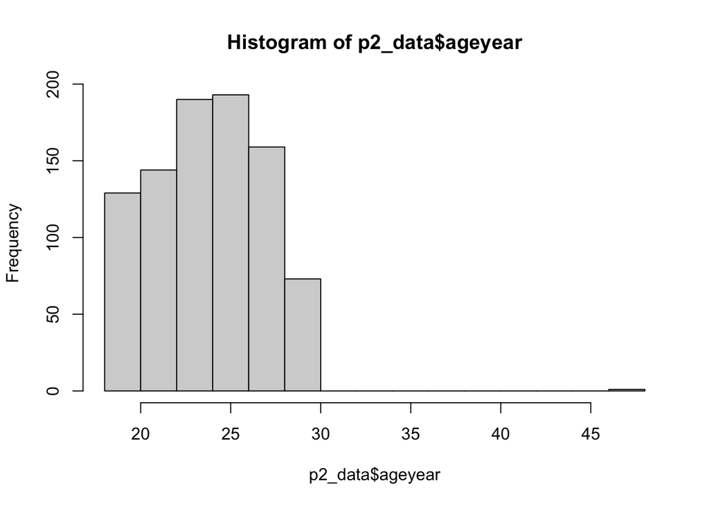

```r
hist(p2_data$ageyear)
```

Now you can see we have the correct range of ages. We can also notice that someone was 47 years old, and should not have qualified for our study. We will remove them.

**Click to see code**

```r
key_columns <- c("responseid", "ageyear")

p2_data <- p2_data %>%
  filter(ageyear <= 30 | is.na(ageyear))

table(p2_data$ageyear)
```

```
 18  19  20  21  22  23  24  25  26  27  28  29
 23  44  62  60  84  87 103  94  99  84  75  73
```

**Click to see code**

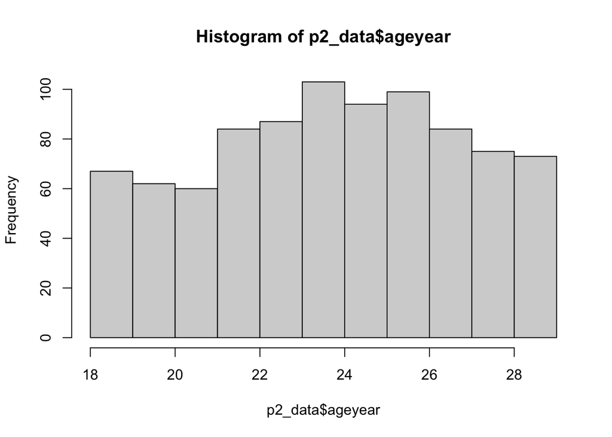

```r
hist(p2_data$ageyear)
```

## Save Results

**Click to see code**

```r
saveRDS(p2_data, "work_data/p2_data.Rds")
```